# (1/3) Linear model

Umut Caglar

2017-06-21

# The Line Fit Function

This is a document invetigates details of linear model

## Data generation

To simulate the results, we will go backwards and firstly generate some data to analyze. To add some randomness to the input data I will use some noise. The input of all package must be in the form of a data frame with at least 2 columns time and intensity.

```r
time=seq(3,24,0.5)

#intensity with Noise
noise_parameter=7
intensity_noise=stats::runif(n = length(time),min = 0,max = 1)*noise_parameter
intensity=sicegar::lineFitFormula(time, slope=4, intersection=-2)
intensity=intensity+intensity_noise

dataInput=data.frame(intensity=intensity,time=time)
```

## Data normalization

This is the first step. Data should be normalized before any fit. I.e time and intensity should be in between 0-1 interval.

There is a nuance

- Time is normalized with respect to maximum value the time parameter takes.

```r
timeRange=max(timeData); timeData=timeData/timeRange
```

- Intensity is normalized with respect to intensity interval

```r
intensityMin = min(dataInput$intensity)
intensityMax = max(dataInput$intensity)
intensityRange = intensityMax - intensityMin

intensityData=dataInput$intensity-intensityMin
intensityData=intensityData/intensityRange
```

The normalization code is

```r
normalizedInput = sicegar::normalizeData(dataInput = dataInput,
                                         dataInputName = "Sample001")
```

Components of the normalization output

```r
head(normalizedInput$timeIntensityData) # the normalized time and intensity data
```

```
##        time  intensity
## 1 0.1250000 0.00000000
## 2 0.1458333 0.01754799
## 3 0.1666667 0.02066282
## 4 0.1875000 0.01198153
## 5 0.2083333 0.05260639
## 6 0.2291667 0.06833362
```

```r
print(normalizedInput$dataScalingParameters) # the normalization parameters that is needed to go back to original scale
```

```
##      timeRange   intensityMin   intensityMax intensityRange
##       24.00000       15.58707       94.13809       78.55103
```

```r
print(normalizedInput$dataInputName) # a useful feature to track the sample in all the process
```

```
## [1] "Sample001"
```

## The figures of raw and normalized datasets

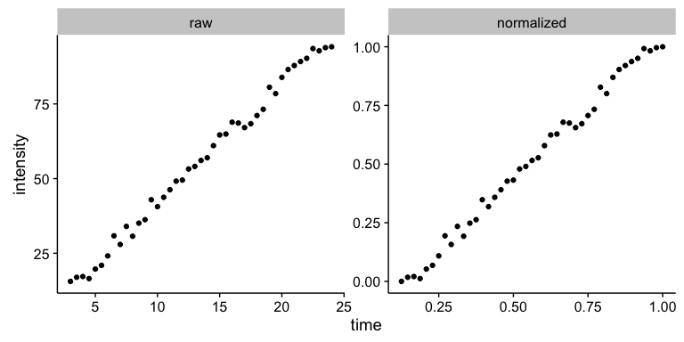

## Line fit of the data

Now it is time to calculate the parameters by using `sicegar::lineFitFunction()`

```r
parameterVector<-sicegar::lineFitFunction(dataInput = normalizedInput, tryCounter = 2)

# Where tryCounter is a tool usually provided by sicegar::fitFunction when the sicegar::lineFitFunction is called from sicegar::fitFunction.

# If tryCounter==1 it took the  start position given by sicegar::fitFunction
# If tryCounter!=1 it generates a random start position from given interval
```

the function outputs a vector that gives information about multiple parameters

```r
print(t(parameterVector))
```

```
##                                      [,1]
## slope_N_Estimate                     "1.229064"
## slope_Std_Error                      "0.01569797"
## slope_t_value                        "78.29448"
## slope_Pr_t                           "2.844619e-46"
## intersection_N_Estimate              "-0.1799898"
## intersection_Std_Error               "0.009718127"
## intersection_t_value                 "-18.52104"
## intersection_Pr_t                    "1.580608e-21"
## residual_Sum_of_Squares              "0.02903872"
## log_likelihood                       "95.94264"
## AIC_value                            "-185.8853"
## BIC_value                            "-180.6017"
## isThisaFit                           "TRUE"
## startVector.slope                    "-32.97216"
## startVector.intersection             "50.24727"
## dataScalingParameters.timeRange      "24"
## dataScalingParameters.intensityMin   "15.58707"
## dataScalingParameters.intensityMax   "94.13809"
## dataScalingParameters.intensityRange "78.55103"
## model                                "linaer"
## intersection_Estimate                "1.448682"
## slope_Estimate                       "4.022677"
```

Here is the brief explanations of the parameters that are given by `sicegar::lineFitFunction` (In different order then than the output vector of the `sicegar::lineFitFunction`)

These are the parameters of the normalization step:

- `dataScalingParameters.timeRange`: Maximum of raw time data
- `dataScalingParameters.intensityMin`: Minimum of raw intensity data
- `dataScalingParameters.intensityMax`: Maximum of raw intensity data
- `dataScalingParameters.intensityRange`: Maximum - Minimum of intensity data

They are the meta summary of the result parameters

- `model`: Gives the used model for fitting
- `isThisaFit`: FALSE means there is not any successful fit. TRUE means there is at least one successful fit

Likelihood maximization algorithm starts from a random initiation point (if tryCounter!=1) and goes down the fitness space by a gradient decent algorithm. These parameters represent the start point of the gradient decent algorithm.

- `startVector.slope`: Slope value of the initiation point
- `startVector.intersection`: Intersection value of the initiation point

For each parameter that needs to fitted by LM algorithm; the algorithm gives a bunch of statistical parameters; including the estimated value of the parameter. **Note: They are for normalized data.**

They are the parameters associated with parameter “slope”

- `slope_N_Estimate`: here N stand for the slope in the normalized scale
- `slope_Std_Error`
- `slope_t_value`
- `slope_Pr_t`

They are the parameters associated with parameter “intersection”

- `intersection_N_Estimate` here N stand for the intersection in the normalized scale
- `intersection_Std_Error`
- `intersection_t_value`
- `intersection_Pr_t`

Here are the fit-parameters that are not related with individual variable that is fitted, but gives information about overal fit.

They are the parameters associated with the quality of the fit.

- `residual_Sum_of_Squares`: Small value indicate better fit
- `log_likelihood`: Higher value indicate a better fit
- `AIC_value`: Smaller value indicate a better fit
- `BIC_value`: Smaller value indicate a better fit

Final results that are relavent to most of the users

They are the fitted values after converting everything from normalized to un-normalized scale.

- `intersection_Estimate`: Intersection estimate for the raw data
- `slope_Estimate`: Slope estimate for the raw data

## Check the results to see if the results are meaningfull

By using the `intersection_Estimate`, `slope_Estimate` parameters of the linefit and the time sequence that we already created we can calculate the intensity values by the help of `sicegar::lineFitFormula()`. We can draw the best line on top of our initial data.

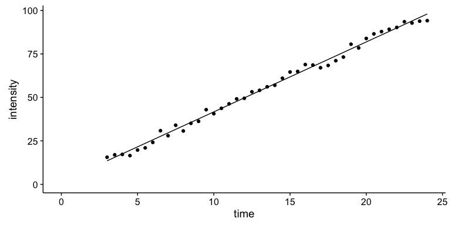

```r
intensityTheoretical=sicegar::lineFitFormula(time,
                                             slope=parameterVector$slope_Estimate,
                                             intersection=parameterVector$intersection_Estimate)
comparisonData=cbind(dataInput,intensityTheoretical)

ggplot2::ggplot(comparisonData)+
  ggplot2::geom_point(aes(x=time, y=intensity))+
  ggplot2::geom_line(aes(x=time,y=intensityTheoretical))+
  ggplot2::expand_limits(x = 0, y = 0)
```